# Python Homework 1

**Due date:** October 5, 11:59 p.m. via GauchoSpace

**Instruction:** Please upload your pdf or html file with your code and result on GauchoSpace with filename "PythonHW1_YOURPERMNUMBER".

The purpose of this Python Homework is to practice with sampling from a distribution with the **NumPy Package**.

*Attention:* Don't forget to import the necessary packages!

```python
import numpy as np
import numpy.random as npr
import matplotlib
from matplotlib import pyplot as plt
import pandas as pd
import seaborn as sns
```

## Problem 1 (6 Points)

1. Simulate 100,000 realizations from the binomial distribution with $N$=2500 trails and success probability $p$=0.45.

```python
# WRITE YOUR OWN CODE HERE! FEEL FREE TO INSERT MORE CELLS!
# ADD SOME COMMENTS TO YOUR CODE!
n = 2500 # trails
p = 0.45 # prob
sample = npr.binomial(n,p, 100000) #100000 simulations
sample
```

```
array([1162, 1132, 1130, ..., 1165, 1093, 1128])
```

1. Compute the empirical mean and the empricial standard deviation of your sample and compare these values with the theoretical values.

```python
# WRITE YOUR OWN CODE HERE! FEEL FREE TO INSERT MORE CELLS!
# ADD SOME COMMENTS TO YOUR CODE!
emp_mean = np.mean(sample)
emp_stdev = np.std(sample)

print(emp_mean)
print(emp_stdev)
```

```
1125.04023
24.86293328525619
```

```python
# theoretical mean
mean = 2500*0.45
print(mean)

# theoretical_std
std = np.sqrt(2500*0.45*(1-0.45))
print(std)
```

```
1125.0
24.8746859276655
```

1. Plot a histogram of your sample with the absolute number of counts for each bin. Choose 50 bins.

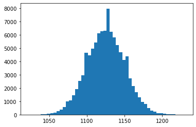

```python
# WRITE YOUR OWN CODE HERE! FEEL FREE TO INSERT MORE CELLS!
# ADD SOME COMMENTS TO YOUR CODE!
sam_hist = plt.hist(sample, bins=50)
sam_hist
```

1. Standardize your sample, that is, subtract the emprical mean and divide by the empricial standard deviation.

```python
# WRITE YOUR OWN CODE HERE! FEEL FREE TO INSERT MORE CELLS!
# ADD SOME COMMENTS TO YOUR CODE!
sta_sample = (sample- emp_mean)/emp_stdev
sta_sample
```

```
array([ 1.48654101,  0.27992554,  0.19948451, ...,  1.60720256,
       -1.28867458,  0.11904348])
```

1. Plot a histogram of your standardized sample with the counts normalized to form a probability density. Choose again 50 bins. Compare your histrogram with the density of the standard normal distribution by inserting its density into the histogram plot.

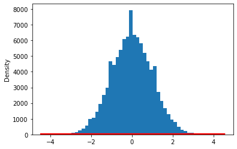

```python
# WRITE YOUR OWN CODE HERE! FEEL FREE TO INSERT MORE CELLS!
# ADD SOME COMMENTS TO YOUR CODE!
sta_sample_hist = plt.hist(sta_sample, bins=50)
sta_sample_hist

sns.distplot(sta_sample, hist=True, kde=True,
             bins=50, color = 'red',
             hist_kws={'edgecolor':'black'},
             kde_kws={'linewidth': 4})
```

## Problem 2 (4 Points)

1. Implement the simulation of a biased 6-sided die which takes the values 1,2,3,4,5,6 with probabilities 1/8,1/12,1/8,1/12,1/4,1/3.

```python
# WRITE YOUR OWN CODE HERE! FEEL FREE TO INSERT MORE CELLS!
# ADD SOME COMMENTS TO YOUR CODE!
die = [1, 2, 3, 4, 5, 6]   # 6-sided die
prob = [1/8,1/12,1/8,1/12,1/4,1/3]  # prob
```

1. Plot a histrogramm with 1,000,000 simulations to check if the relative counts of each number is approximately equal to the corresponding specified probabilities.

*Remark:* Specify the bins of your histogram correctly.

```
[0.12516, 0.083301, 0.125319, 0.08347, 0.250295, 0.332455]
```

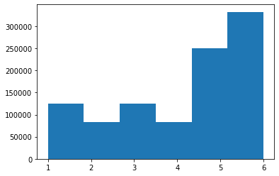

```python
# WRITE YOUR OWN CODE HERE! FEEL FREE TO INSERT MORE CELLS!
# ADD SOME COMMENTS TO YOUR CODE!

rolls = list(np.random.choice(die, 1000000, p= prob)) # random variable
plt.hist(rolls, bins = 6)  # plot

counts = [rolls.count(i) for i in die] #count each side

prob2 = [counts[i]/1000000.0 for i in range(6)] #compute each side prob
prob2
```